# Assignment 06: Generalized Linear Models-Mixed Effects

Jason Edelkind

2023-10-15

[figure not shown]

# Reading in Data

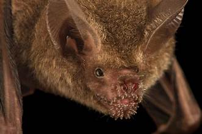

```r
bat<-read.csv("..\\data\\bat.csv")
```

My dataset contains information from an experiment exploring whether fringe-lipped bats switch their targeted prey when presented with a new auditory cue mid-flight, and how both mid-flight prey switching and the distance between the new and old auditory cue influence attack accuracy, flight time, and capture success. For this assignment, I will be investigating the influence of secondary call treatment and prey switching on attack accuracy, using individual ID as a random effect.

# Summarizing the Data

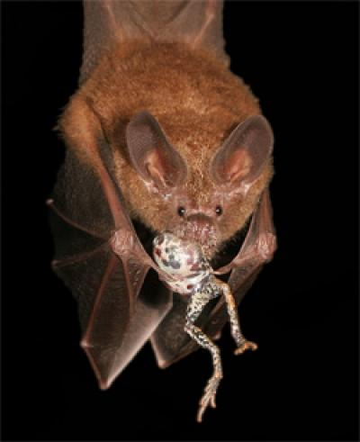

| switched_prey | Treatment | n | mean_error | se_move |
| --- | --- | --- | --- | --- |
| N | S1 | 37 | 36.39081 | 6.833242 |
| N | S3 | 64 | 55.19406 | 5.398189 |
| N | SN | 112 | 46.60411 | 3.713929 |
| N | SS | 155 | 28.39542 | 2.280391 |
| Y | S1 | 133 | 24.18293 | 2.175113 |
| Y | S3 | 78 | 66.74974 | 4.814638 |
| Y | SN | 18 | 177.00000 | 0.000000 |
| Y | SS | 10 | 177.00000 | 0.000000 |

# Linear Mixed Effects Model

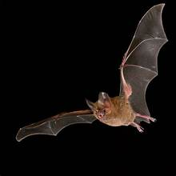

|  | Sum Sq | Mean Sq | NumDF | DenDF | F value | Pr(>F) |
| --- | --- | --- | --- | --- | --- | --- |
| switched_prey | 334596.5 | 334596.5 | 1 | 598.4225 | 292.47829 | 1.105449e-53 |
| Treatment | 332912.2 | 110970.7 | 3 | 594.0332 | 97.00199 | 4.172478e-51 |
| switched_prey:Treatment | 342885.1 | 114295.0 | 3 | 596.5227 | 99.90784 | 2.094915e-52 |

There is a significant impact of both treatment and prey switching on location error, as well as the interaction of the two variables.

```
## Linear mixed model fit by REML. t-tests use Satterthwaite's method [
## lmerModLmerTest]
## Formula: location_error ~ switched_prey * Treatment + (1 | ID)
##    Data: bat
##
## REML criterion at convergence: 5958
##
## Scaled residuals:
##     Min      1Q  Median      3Q     Max
## -1.9952 -0.7095 -0.1653  0.5490  3.2116
##
## Random effects:
##  Groups   Name        Variance Std.Dev.
##  ID       (Intercept)   22.6    4.754
##  Residual             1144.0   33.823
## Number of obs: 607, groups:  ID, 14
##
## Fixed effects:
##                            Estimate Std. Error      df t value Pr(>|t|)
## (Intercept)                  36.432      5.727 409.913   6.362 5.34e-10 ***
## switched_preyY              -12.147      6.318 596.925  -1.923  0.05501 .
## TreatmentS3                  18.290      7.020 596.369   2.605  0.00941 **
## TreatmentSN                  10.012      6.451 597.557   1.552  0.12117
## TreatmentSS                  -8.198      6.214 595.216  -1.319  0.18758
## switched_preyY:TreatmentS3   24.395      8.553 598.632   2.852  0.00449 **
## switched_preyY:TreatmentSN  143.054     10.713 598.009  13.353  < 2e-16 ***
## switched_preyY:TreatmentSS  163.956     12.819 598.991  12.790  < 2e-16 ***
## ---
## Signif. codes:  0 '***' 0.001 '**' 0.01 '*' 0.05 '.' 0.1 ' ' 1
##
## Correlation of Fixed Effects:
##             (Intr) swtc_Y TrtmS3 TrtmSN TrtmSS s_Y:TS3 s_Y:TSN
## swtchd_pryY -0.862
## TreatmentS3 -0.774  0.702
## TreatmentSN -0.845  0.768  0.689
## TreatmentSS -0.876  0.796  0.714  0.780
## swtch_Y:TS3  0.635 -0.736 -0.824 -0.566 -0.586
## swtch_Y:TSN  0.511 -0.592 -0.416 -0.606 -0.472  0.436
## swtch_Y:TSS  0.427 -0.495 -0.350 -0.385 -0.488  0.366   0.300
```

Interpretation: In treatment group S1, the Prey Switch No group is significantly different from zero, though the Prey Switch Yes group is almost significantly different from zero in group S1. For the switched prey No group, treatments SN and SS are not significantly different, though treatment S3 is significantly different. For the switched prey yes group, treatments S3, SN, and SS are significantly different from zero.

# Autoplot

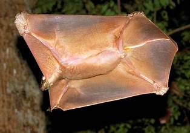

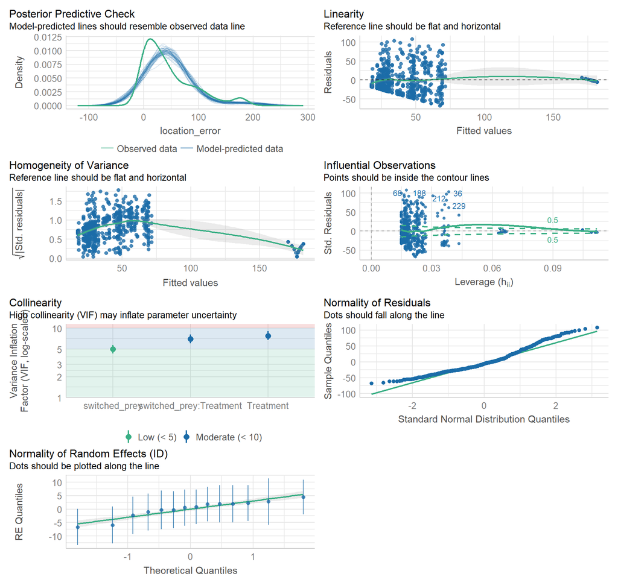

# Model-Adjusted Means

```
## switched_prey = N:
##  Treatment emmean    SE    df lower.CL upper.CL
##  S1          36.4  5.74 416.7     25.2     47.7
##  S3          54.7  4.47 237.3     45.9     63.5
##  SN          46.4  3.47 116.9     39.6     53.3
##  SS          28.2  3.02  75.2     22.2     34.2
##
## switched_prey = Y:
##  Treatment emmean    SE    df lower.CL upper.CL
##  S1          24.3  3.22  91.8     17.9     30.7
##  S3          67.0  4.08 188.0     58.9     75.0
##  SN         177.4  8.12 549.2    161.4    193.3
##  SS         180.0 10.90 574.1    158.6    201.5
##
## Degrees-of-freedom method: kenward-roger
## Confidence level used: 0.95
```

|  | Treatment | switched_prey | emmean | SE | df | lower.CL | upper.CL |
| --- | --- | --- | --- | --- | --- | --- | --- |
| 1 | S1 | N | 36.43198 | 5.735230 | 416.70262 | 25.15839 | 47.70556 |
| 2 | S3 | N | 54.72164 | 4.470268 | 237.33082 | 45.91517 | 63.52811 |
| 3 | SN | N | 46.44422 | 3.473879 | 116.85909 | 39.56430 | 53.32414 |
| 4 | SS | N | 28.23400 | 3.018112 | 75.23309 | 22.22192 | 34.24608 |
| 5 | S1 | Y | 24.28479 | 3.219848 | 91.84636 | 17.88975 | 30.67983 |
| 6 | S3 | Y | 66.96904 | 4.079411 | 188.04125 | 58.92175 | 75.01633 |
| 7 | SN | Y | 177.35144 | 8.120986 | 549.17563 | 161.39944 | 193.30344 |
| 8 | SS | Y | 180.04302 | 10.903108 | 574.06866 | 158.62817 | 201.45787 |

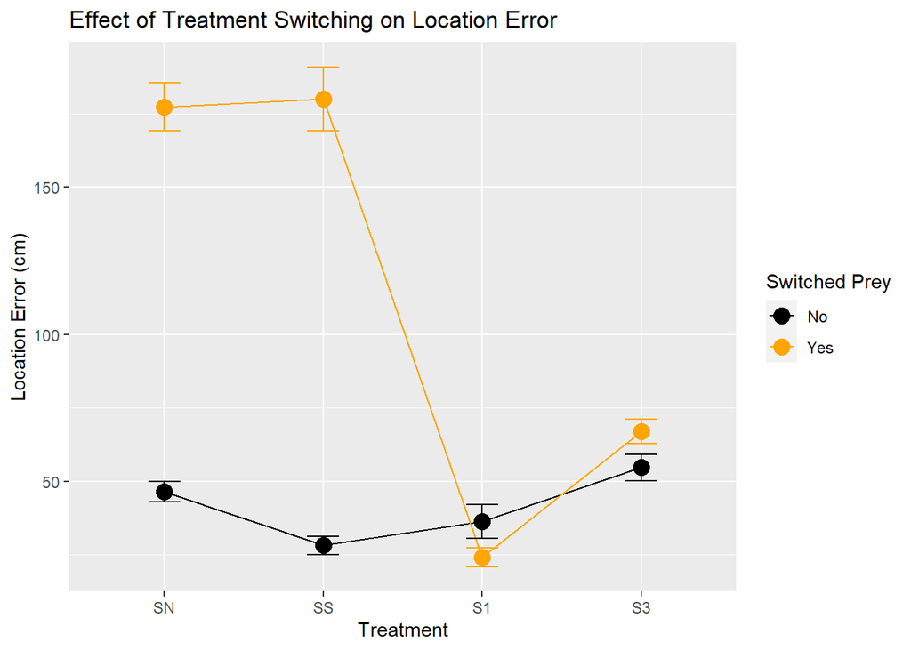

Unfortunately, there appears to be an interaction effect in my data. How does treatment type affect location error? Well, it depends on the treatment group and whether the bat switched prey or not. In treatment group S1 prey switching led to a decrease in location error, though the difference is not significant (12.1 cm,P=0.0554). In all other treatment groups, prey switching led to an increase in location error (S3: 12.2 cm,p=0.0357), in the case of groups SN and SS, a very large increase in location error (130.9 cm,p<0.001, and 151.8 cm,p<0.001 respectively).

# Pairwise Comparisons

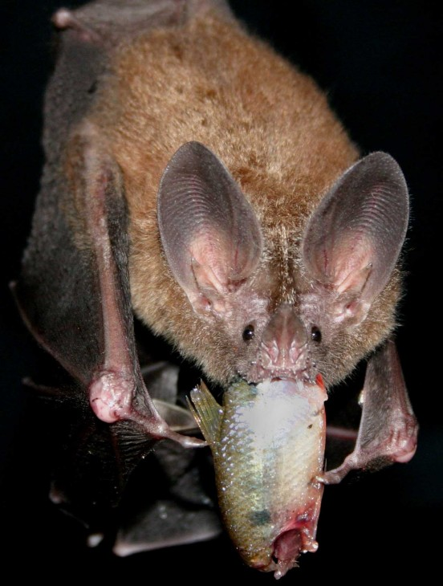

```
## Treatment = S1:
##  contrast estimate    SE  df t.ratio p.value
##  N - Y        12.1  6.33 597   1.919  0.0554
##
## Treatment = S3:
##  contrast estimate    SE  df t.ratio p.value
##  N - Y       -12.2  5.82 594  -2.105  0.0357
##
## Treatment = SN:
##  contrast estimate    SE  df t.ratio p.value
##  N - Y      -130.9  8.65 597 -15.133  <.0001
##
## Treatment = SS:
##  contrast estimate    SE  df t.ratio p.value
##  N - Y      -151.8 11.17 599 -13.588  <.0001
##
## Degrees-of-freedom method: kenward-roger
```

This table looks at pairs within treatment groups and reiterates what I just said, there is a significant difference between the no prey switch and yes prey switch groups for treatments S3, SN, and SS.

```
## switched_prey = N:
##  contrast estimate    SE  df t.ratio p.value
##  S1 - S3    -18.29  7.03 596  -2.600  0.0469
##  S1 - SN    -10.01  6.46 598  -1.549  0.4090
##  S1 - SS      8.20  6.22 595   1.317  0.5522
##  S3 - SN      8.28  5.35 599   1.547  0.4101
##  S3 - SS     26.49  5.07 598   5.221  <.0001
##  SN - SS     18.21  4.21 592   4.329  0.0001
##
## switched_prey = Y:
##  contrast estimate    SE  df t.ratio p.value
##  S1 - S3    -42.68  4.85 595  -8.799  <.0001
##  S1 - SN   -153.07  8.53 594 -17.935  <.0001
##  S1 - SS   -155.76 11.22 599 -13.881  <.0001
##  S3 - SN   -110.38  8.89 595 -12.411  <.0001
##  S3 - SS   -113.07 11.50 599  -9.835  <.0001
##  SN - SS     -2.69 13.41 594  -0.201  0.9971
##
## Degrees-of-freedom method: kenward-roger
## P value adjustment: tukey method for comparing a family of 4 estimates
```

```
## $emmeans
##  Treatment switched_prey emmean    SE    df lower.CL upper.CL
##  S1        N               36.4  5.74 416.7     25.2     47.7
##  S3        N               54.7  4.47 237.3     45.9     63.5
##  SN        N               46.4  3.47 116.9     39.6     53.3
##  SS        N               28.2  3.02  75.2     22.2     34.2
##  S1        Y               24.3  3.22  91.8     17.9     30.7
##  S3        Y               67.0  4.08 188.0     58.9     75.0
##  SN        Y              177.4  8.12 549.2    161.4    193.3
##  SS        Y              180.0 10.90 574.1    158.6    201.5
##
## Degrees-of-freedom method: kenward-roger
## Confidence level used: 0.95
##
## $contrasts
##  contrast    estimate    SE  df t.ratio p.value
##  S1 N - S3 N   -18.29  7.03 596  -2.600  0.1577
##  S1 N - SN N   -10.01  6.46 598  -1.549  0.7804
##  S1 N - SS N     8.20  6.22 595   1.317  0.8922
##  S1 N - S1 Y    12.15  6.33 597   1.919  0.5382
##  S1 N - S3 Y   -30.54  6.81 598  -4.487  0.0002
##  S1 N - SN Y  -140.92  9.76 594 -14.438  <.0001
##  S1 N - SS Y  -143.61 12.17 598 -11.804  <.0001
##  S3 N - SN N     8.28  5.35 599   1.547  0.7814
##  S3 N - SS N    26.49  5.07 598   5.221  <.0001
##  S3 N - S1 Y    30.44  5.20 599   5.854  <.0001
##  S3 N - S3 Y   -12.25  5.82 594  -2.105  0.4128
##  S3 N - SN Y  -122.63  9.08 596 -13.501  <.0001
##  S3 N - SS Y  -125.32 11.66 599 -10.751  <.0001
##  SN N - SS N    18.21  4.21 592   4.329  0.0005
##  SN N - S1 Y    22.16  4.35 592   5.093  <.0001
##  SN N - S3 Y   -20.52  5.02 597  -4.085  0.0013
##  SN N - SN Y  -130.91  8.65 597 -15.133  <.0001
##  SN N - SS Y  -133.60 11.33 599 -11.793  <.0001
##  SS N - S1 Y     3.95  4.00 590   0.986  0.9763
##  SS N - S3 Y   -38.74  4.72 596  -8.200  <.0001
##  SS N - SN Y  -149.12  8.46 594 -17.620  <.0001
##  SS N - SS Y  -151.81 11.17 599 -13.588  <.0001
##  S1 Y - S3 Y   -42.68  4.85 595  -8.799  <.0001
##  S1 Y - SN Y  -153.07  8.53 594 -17.935  <.0001
##  S1 Y - SS Y  -155.76 11.22 599 -13.881  <.0001
##  S3 Y - SN Y  -110.38  8.89 595 -12.411  <.0001
##  S3 Y - SS Y  -113.07 11.50 599  -9.835  <.0001
##  SN Y - SS Y    -2.69 13.41 594  -0.201  1.0000
##
## Degrees-of-freedom method: kenward-roger
## P value adjustment: tukey method for comparing a family of 8 estimates
```

[video not shown]

Bonus points if you caught the colugo

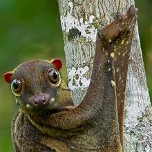